# Question

Se ha entrevistado a 50 adolescentes sobre los géneros musicales que escuchan.

- 17 de ellos escuchan Rap,
- 18 escuchan Tango, y
- 21 Salsa.

Además sabemos que

- 6 de ellos escuchan Rap y Tango,
- 6 escuchan Rap y Salsa, y
- 3 solamente Tango y Salsa.

Por último sabemos que solamente 3 escuchan los tres géneros musicales.

Considerando esa información:

## Answerlist

- ¿Cuántas personas escuchan solamente Rap y Tango?
- ¿Cuántas personas escuchan exactamente dos géneros musicales?
- ¿Cuál es el número de entrevistados que no escuchan Tango ni Salsa?
- ¿Cuántos adolescentes no escuchan ninguno de estos géneros musicales?

# Solution

Para resolver este problema, analizamos el diagrama de Venn que representa la intersección de los tres conjuntos: Rap, Tango y Salsa.

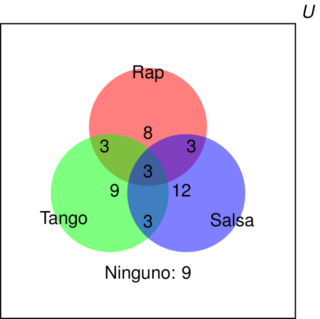

Explicación detallada:

1. ¿Cuántas personas escuchan solamente Rap y Tango?: 3
2. ¿Cuántas personas escuchan exactamente dos géneros musicales?: 9
3. ¿Cuál es el número de entrevistados que no escuchan Tango ni Salsa?: 17
4. ¿Cuántos adolescentes no escuchan ninguno de estos géneros musicales?: 9

## Answerlist

- La respuesta es 3.
- La respuesta es 9.
- La respuesta es 17.
- La respuesta es 9.

# Meta-information

exname: Géneros musicales  
extype: cloze  
exclozetype: num|num|num|num  
exsolution: 3|9|17|9  
extol: 0  
exsection: Diagrama de Venn